# Code-through-assignemnt-Goel-527

Sunayna Goel

February 24, 2020

# Introduction

**Text Mining** in R makes it possible to identify most frequently used keywords in a text paragraph. It allows a user to create **word cloud**, or **text cloud** as a visual representation of these keywords . **Word cloud** is a visually engaging and powerful communication tool. Text mining packages such as **qunateda**, **tm**, **stringr** provide robust tools for text analysis by making it easy to manipulate data, manage corpus and analyse keywords. Packages **wordcloud** and **wordcloud2** make it possible to quickly visualise keywords as word-cloud.

## Getting started

The following packages and libraries are needed for this purpose.

```r
# install.packages() cannot be included in an RMD file when knitting

#install.packages("quanteda")
#install.packages ("wordcloud")
#install.packages ("wordcloud2")
#install.packages("tidyverse")

#load_packages

library( quanteda )  ## Manage and analyse textual data
library(wordcloud)   ## Plots a cloud of words shared across documents
library(wordcloud2)  ## Provides traditional wordcloud with HTML5
library(tidyverse)   ## Includes popular packages used in data analyses
```

## Data download

```r
#Load local .txt file
setwd( "/Users/sunaynaagarwal/Desktop" )
organic.text<- readLines("Textanalysis.txt",warn=FALSE )
organic.text
```

[output not shown]

## Data Manipulation

In this step the text document is converted to lower case. It is then turned to **corpus** for data manipulation. Punctuation and filler words are removed.

```r
#convert in lower case
organic.text <- tolower (organic.text)

#make corpus
corp.organic <- corpus(organic.text)

#corpus content
corp.organic

# remove punctuation
tokens <- tokens( corp.organic, what="word", remove_punct=TRUE )
head( tokens )

# remove filler words like the, and, a, to
tokens <- tokens_remove( tokens, c( stopwords("english"), "nbsp" ), padding=F )

head( tokens )
```

[output not shown]

### Top keywords

Identify top 50 keywords.

```r
#Top 10 token without stemming
my.matrix<-tokens %>% dfm( stem=F ) %>% topfeatures(n=50 )
head(my.matrix)
```

```
##  natural  organic products     skin     time skincare
##       28       22       16       13       10        9
```

## Package Wordcloud

### Data Matrix

Convert the output in a matrix for generating the **Word Cloud**

```r
mat <- as.matrix(my.matrix)
my.frequency <- sort(rowSums(mat),decreasing=TRUE)
my.data <- data.frame(word = names(my.frequency),freq=my.frequency)
head(my.data, 7)
```

|  | word | freq |
| --- | --- | --- |
| natural | natural | 28 |
| organic | organic | 22 |
| products | products | 16 |
| skin | skin | 13 |
| time | time | 10 |
| skincare | skincare | 9 |
| ingredients | ingredients | 9 |

### Output Word Cloud

Wordcloud allows the user to generate cloud with keywords in random order or in non-random order keeping high frequency words towards the center. There are other arguments to adjust the colors and rotation of the keywords in the actual cloud.

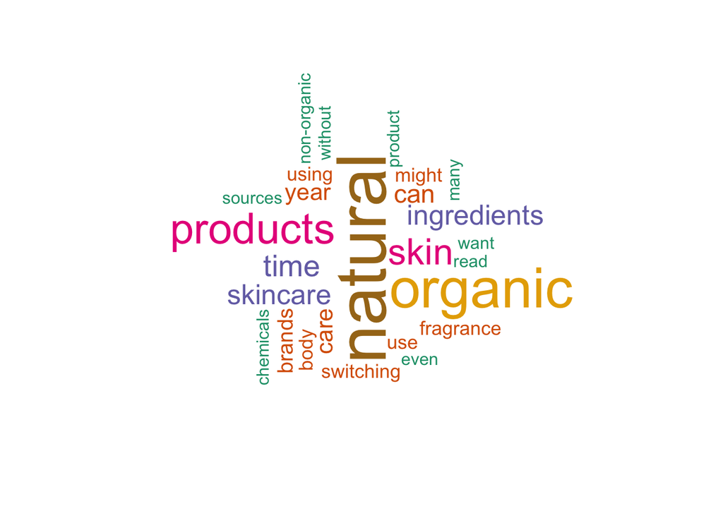

```r
# reproduces output
set.seed(101)
# generate word cloud using keywords at random
wordcloud(words = my.data$word, freq = my.data$freq, rot.per=0.30, colors=brewer.pal(7, "Dark2"), min.freq=4, max.words = 200, random.order=FALSE)
```

## Package Wordcloud2

### Data Table

Convert the output to a datatable for generating the **Word Cloud**

```r
#convert tokens to a datatable
my.df<-tokens %>% dfm( stem=F ) %>% topfeatures(n=50 )
data.table<- data.frame( word=names(my.df), freq=my.df,row.names=NULL )
```

### Output WordCloud

Wordcloud2 offer eveything that wordcloud offers plus more. It allows user to chnage background color and produce output in a distinctive shape.

```r
# reproduces output
set.seed(1234)
wordcloud2(data= data.table, color=rep_len( c("forestgreen","darkcyan"), nrow(demoFreq)),size = 0.7, shape = 'pentagon',minRotation = -pi/8, maxRotation = -pi/8, rotateRatio = .7, backgroundColor = 'khaki')
```

[interactive chart not shown]

## Acknowledgement

The following resources were used to create this tutorial for the assignment. To explore more please click the following links.

[STHDA](http://www.sthda.com/english/wiki/text-mining-and-word-cloud-fundamentals-in-r-5-simple-steps-you-should-know)

[cran.rstudio- WordCloud](https://cran.r-project.org/web/packages/wordcloud/wordcloud.pdf)

[cran.rstudio- WordCloud2](https://cran.r-project.org/web/packages/wordcloud2/vignettes/wordcloud.html)

[rGraph Gallery](https://www.r-graph-gallery.com/wordcloud.html)